# Forecast Daily Bike Rental Demand Using Time Series Models

Souriya Khaosanga

2024-07-21

### 1. Optimize Data Loading and Processing

Ensure data is efficiently loaded and processed.

```r
# Load the data
day_data <- read.csv("day.csv")

# Convert the date column to Date type
day_data$dteday <- as.Date(day_data$dteday, format = "%Y-%m-%d")

# Convert to time series object
ts_data <- ts(day_data$cnt, frequency = 365)
```

### 2. Resolve Conflicts and Suppress Warnings

Use the `conflicted` package to handle function conflicts and suppress unnecessary warnings.

```r
# Import required packages
library(tidyverse)
library(lubridate)
library(timetk)
library(forecast)
```

```r
library(tseries)
library(ggplot2)
library(conflicted)

# Resolve conflicts
conflict_prefer("filter", "dplyr")
```

```
## [conflicted] Will prefer dplyr::filter over any other package.
```

```r
conflict_prefer("lag", "dplyr")
```

```
## [conflicted] Will prefer dplyr::lag over any other package.
```

```r
conflict_prefer("decompose", "stats")
```

```
## [conflicted] Will prefer stats::decompose over any other package.
```

```r
# Suppress package startup messages
suppressPackageStartupMessages(library(tidyverse))
suppressPackageStartupMessages(library(forecast))
suppressPackageStartupMessages(library(tseries))
```

### 3. Efficiently Create and Plot Time Series

Ensure efficient plotting and avoid unnecessary complexity.

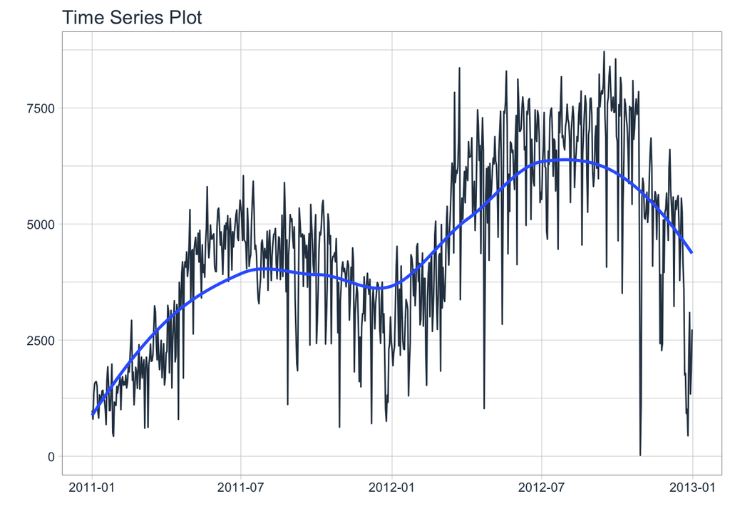

```r
# Interactive time series plot using timetk
day_data %>%
  tk_tbl() %>%
  plot_time_series(dteday, cnt, .interactive = FALSE)  # Turn off interactivity for speed
```

### 4. Simplify and Optimize Model Fitting

Check stationarity before fitting the model to avoid unnecessary computations.

```r
# Check stationarity using the Augmented Dickey-Fuller test
adf_test <- adf.test(ts_data, alternative = "stationary")
print(adf_test)
```

```
##
##  Augmented Dickey-Fuller Test
##
## data:  ts_data
## Dickey-Fuller = -1.6351, Lag order = 9, p-value = 0.7327
## alternative hypothesis: stationary
```

```r
# Fit ARIMA model only if necessary
if (adf_test$p.value > 0.05) {
  ts_data_diff <- diff(ts_data)  # Differencing to make it stationary
} else {
  ts_data_diff <- ts_data
}

fit <- auto.arima(ts_data_diff)
summary(fit)
```

```
## Series: ts_data_diff
## ARIMA(1,0,1) with zero mean
##
## Coefficients:
##          ar1      ma1
##       0.3584  -0.8896
## s.e.  0.0423   0.0192
##
## sigma^2 = 857769:  log likelihood = -6021.96
## AIC=12049.91   AICc=12049.94   BIC=12063.69
##
## Training set error measures:
##                    ME     RMSE      MAE      MPE    MAPE      MASE       ACF1
## Training set 12.89471 924.8887 648.5267 164.5701 245.294 0.5930705 0.01116795
```

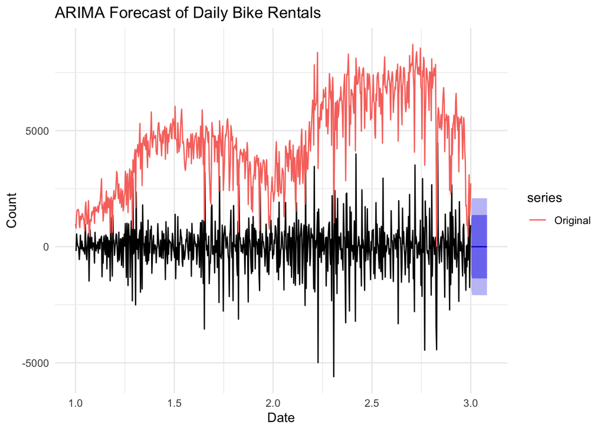

```r
# Forecast the next 30 days
forecasted_values <- forecast(fit, h = 30)
autoplot(forecast(fit, h = 30)) +
  autolayer(ts_data, series = "Original") +
  labs(title = "ARIMA Forecast of Daily Bike Rentals", x = "Date", y = "Count") +
  theme_minimal()
```

# About Data Analysis Report

This RMarkdown file contains the report of the data analysis done for the project on forecasting daily bike rental demand using time series models in R. It contains analysis such as data exploration, summary statistics, and building the time series models. The final report was completed on 2024-07-21.

**Data Description:**

This dataset contains the daily count of rental bike transactions between years 2011 and 2012 in Capital Bikeshare system with the corresponding weather and seasonal information.

**Data Source:** [Bike Sharing Dataset](https://archive.ics.uci.edu/ml/datasets/bike+sharing+dataset)

**Relevant Paper:**

Fanaee-T, Hadi, and Gama, Joao. Event labeling combining ensemble detectors and background knowledge, Progress in Artificial Intelligence (2013): pp. 1-15, Springer Berlin Heidelberg.

# Task One: Load and Explore the Data

## Load Data and Install Packages

```r
# Import required packages
suppressPackageStartupMessages(library(tidyverse))
suppressPackageStartupMessages(library(lubridate))
suppressPackageStartupMessages(library(timetk))
suppressPackageStartupMessages(library(forecast))
suppressPackageStartupMessages(library(tseries))
suppressPackageStartupMessages(library(ggplot2))
suppressPackageStartupMessages(library(conflicted))

# Resolve conflicts
conflict_prefer("filter", "dplyr")
```

```
## [conflicted] Removing existing preference.
## [conflicted] Will prefer dplyr::filter over any other package.
```

```r
conflict_prefer("lag", "dplyr")
```

```
## [conflicted] Removing existing preference.
## [conflicted] Will prefer dplyr::lag over any other package.
```

```r
conflict_prefer("decompose", "stats")
```

```
## [conflicted] Removing existing preference.
## [conflicted] Will prefer stats::decompose over any other package.
```

```r
# Load the data
day_data <- read.csv("day.csv")
hour_data <- read.csv("hour.csv")

# Convert the date column to Date type
day_data$dteday <- as.Date(day_data$dteday, format = "%Y-%m-%d")

# Convert to time series object
ts_data <- ts(day_data$cnt, frequency = 365)
```

## Describe and Explore the Data

```r
# Display the structure and summary of the data
str(day_data)
```

```
## 'data.frame':    731 obs. of  16 variables:
##  $ instant   : int  1 2 3 4 5 6 7 8 9 10 ...
##  $ dteday    : Date, format: "2011-01-01" "2011-01-02" ...
##  $ season    : int  1 1 1 1 1 1 1 1 1 1 ...
##  $ yr        : int  0 0 0 0 0 0 0 0 0 0 ...
##  $ mnth      : int  1 1 1 1 1 1 1 1 1 1 ...
##  $ holiday   : int  0 0 0 0 0 0 0 0 0 0 ...
##  $ weekday   : int  6 0 1 2 3 4 5 6 0 1 ...
##  $ workingday: int  0 0 1 1 1 1 1 0 0 1 ...
##  $ weathersit: int  2 2 1 1 1 1 2 2 1 1 ...
##  $ temp      : num  0.344 0.363 0.196 0.2 0.227 ...
##  $ atemp     : num  0.364 0.354 0.189 0.212 0.229 ...
##  $ hum       : num  0.806 0.696 0.437 0.59 0.437 ...
##  $ windspeed : num  0.16 0.249 0.248 0.16 0.187 ...
##  $ casual    : int  331 131 120 108 82 88 148 68 54 41 ...
##  $ registered: int  654 670 1229 1454 1518 1518 1362 891 768 1280 ...
##  $ cnt       : int  985 801 1349 1562 1600 1606 1510 959 822 1321 ...
```

```r
summary(day_data)
```

```
##     instant          dteday               season            yr
##  Min.   :  1.0   Min.   :2011-01-01   Min.   :1.000   Min.   :0.0000
##  1st Qu.:183.5   1st Qu.:2011-07-02   1st Qu.:2.000   1st Qu.:0.0000
##  Median :366.0   Median :2012-01-01   Median :3.000   Median :1.0000
##  Mean   :366.0   Mean   :2012-01-01   Mean   :2.497   Mean   :0.5007
##  3rd Qu.:548.5   3rd Qu.:2012-07-01   3rd Qu.:3.000   3rd Qu.:1.0000
##  Max.   :731.0   Max.   :2012-12-31   Max.   :4.000   Max.   :1.0000
##       mnth          holiday           weekday        workingday
##  Min.   : 1.00   Min.   :0.00000   Min.   :0.000   Min.   :0.000
##  1st Qu.: 4.00   1st Qu.:0.00000   1st Qu.:1.000   1st Qu.:0.000
##  Median : 7.00   Median :0.00000   Median :3.000   Median :1.000
##  Mean   : 6.52   Mean   :0.02873   Mean   :2.997   Mean   :0.684
##  3rd Qu.:10.00   3rd Qu.:0.00000   3rd Qu.:5.000   3rd Qu.:1.000
##  Max.   :12.00   Max.   :1.00000   Max.   :6.000   Max.   :1.000
##    weathersit         temp             atemp              hum
##  Min.   :1.000   Min.   :0.05913   Min.   :0.07907   Min.   :0.0000
##  1st Qu.:1.000   1st Qu.:0.33708   1st Qu.:0.33784   1st Qu.:0.5200
##  Median :1.000   Median :0.49833   Median :0.48673   Median :0.6267
##  Mean   :1.395   Mean   :0.49538   Mean   :0.47435   Mean   :0.6279
##  3rd Qu.:2.000   3rd Qu.:0.65542   3rd Qu.:0.60860   3rd Qu.:0.7302
##  Max.   :3.000   Max.   :0.86167   Max.   :0.84090   Max.   :0.9725
##    windspeed           casual         registered        cnt
##  Min.   :0.02239   Min.   :   2.0   Min.   :  20   Min.   :  22
##  1st Qu.:0.13495   1st Qu.: 315.5   1st Qu.:2497   1st Qu.:3152
##  Median :0.18097   Median : 713.0   Median :3662   Median :4548
##  Mean   :0.19049   Mean   : 848.2   Mean   :3656   Mean   :4504
##  3rd Qu.:0.23321   3rd Qu.:1096.0   3rd Qu.:4776   3rd Qu.:5956
##  Max.   :0.50746   Max.   :3410.0   Max.   :6946   Max.   :8714
```

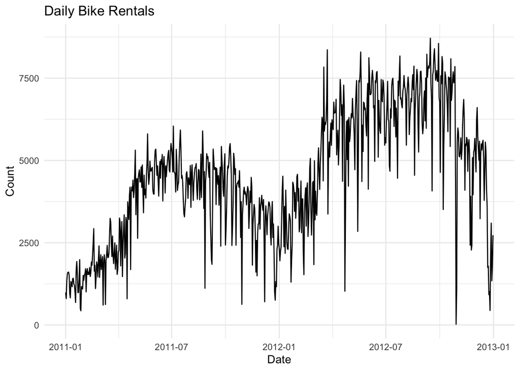

```r
# Plot the rental count over time
ggplot(day_data, aes(x = dteday, y = cnt)) +
  geom_line() +
  labs(title = "Daily Bike Rentals", x = "Date", y = "Count") +
  theme_minimal()
```